# phylogeo basics.

Analysis of data generated using sequencing of microbial genes has provided a fertile ground for exploring the large fraction of bacterial life that remains uncultured. The phylogeo package provides investigators with a way to explore the geographic components of their microbial gene data by building on the powerful phyloseq package which provides a framework for organizing data while combining it with the elegance of the [ggplot](http://ggplot2.org/) plotting package.

## Datasets in Phylogeo

phylogeo has three datasets.

These datasets have geographic coordinates and are suitable for illustrating the features of the phylogeo package, and they can be loaded using the `data()` command.

```r
library(ggplot2)
library(gridExtra)
library(phylogeo)

data(mountainsoil)
data(batmicrobiome)
data(epoxomicin_KS)
```

## phyloseq mapping functions

phylogeo provides a series of functions that allow investigators to explore the geographic dimension of their data. As such, the primary requirement for using phylogeo is the presence of Latitude and Longitude columns in your `sample_data` table. If these are present the following functions become available to you:

- `map_phyloseq()` can visualize your sample locations on a map
- `map_network()` will connect samples based on a specified ecological distance
- `map_tree()` will draw a paired plot of a phylogenetic tree and the location of those samples
- `map_clusters()` will cluster your sequences into *k* clusters and facet-map each cluster
- `plot_distance()` will plot the pairwise distances between samples using ecological and great circle distance

### map_phyloseq

*map_phyloseq* provides a way to quickly look at your data by mapping it. Because no calculations are done to the underlying data, drawing a map using this command is quite quick. The mapping in this command (and all commands) is handled by the `map_data` function of ggplot. This style of mapping allows zooming in by `region` using a lookup table of country-names. Other ggplot goodies like coloring by a variable are all available as is a set of convenience functions that allows you to jitter points that are overlapping at the scale you are interested in. Two examples showing how these features can be used to zoom into a region, separate samples and look at the distribution of a variable (“PH”) in the phyloseq `sample_data` table.

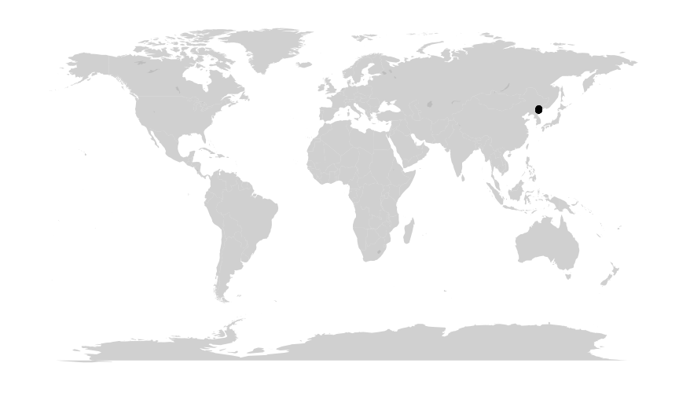

```r
#high level world map
map_phyloseq(mountainsoil)
```

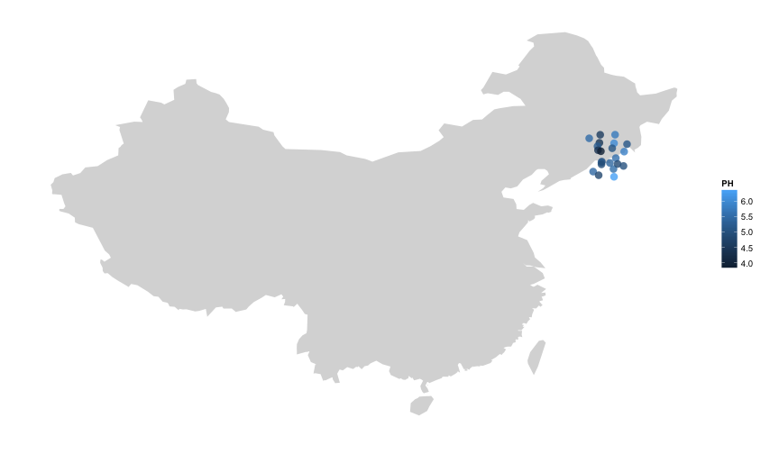

```r
#zoomed in map, coloed by pH and jittered in order to see the points better
map_phyloseq(mountainsoil, region="china", jitter=TRUE, jitter.x=2,jitter.y=2, color="PH")
```

### map_network

The goal of the *map_network* function is to visualize the relatedness of ecological samples. It does this using the same technique in phyloseq's *plot_net* and *plot_network* functions, namely, it will calculate an ecological distance between samples. Instead of using a network layout algorithm, however, phylogeo will place points by their geographic location. If the points are crowded, they can be jittered to space them apart. A number of configuration options are available to control the appearance of the points and lines.

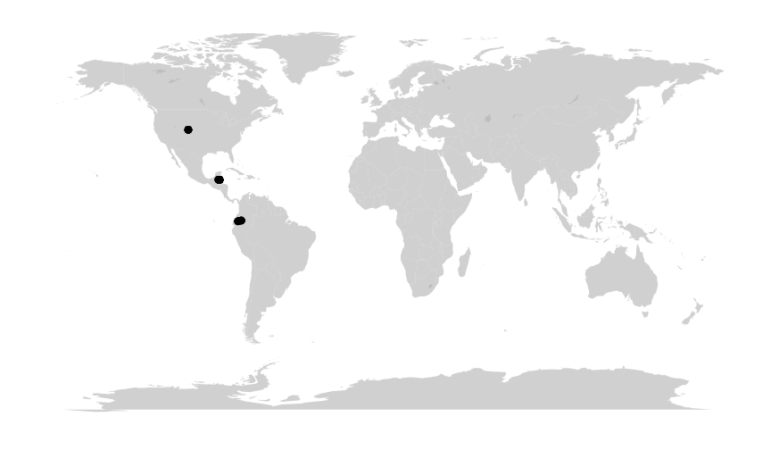

```r
#simple network map without lines
map_network(batmicrobiome)
```

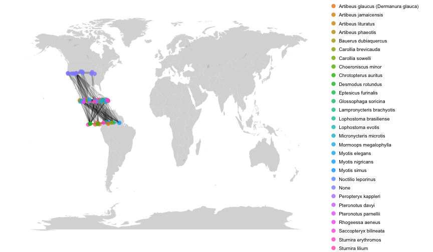

```r
#play with the jitter and cutoff to get a better view
map_network(batmicrobiome, color="SCIENTIFIC_NAME", jitter=TRUE, jitter.x=20,jitter.y=1, lines=TRUE, line_weight = 0.2)
```

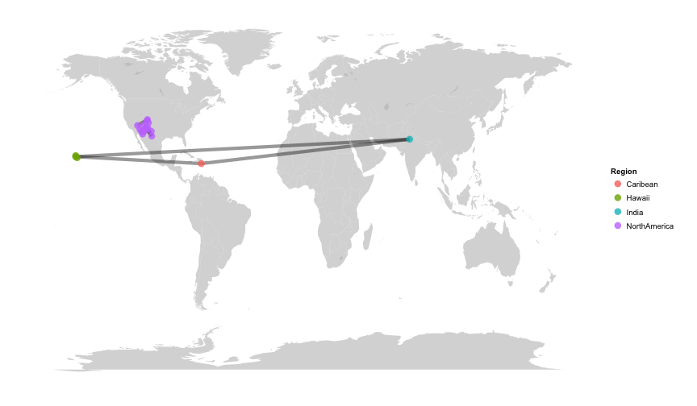

```r
#map-network with a different dataset
map_network(epoxomicin_KS, color="Region", jitter=TRUE, lines=TRUE, line_weight = 2)
```

One current downside to the current mapping setup is that the `region` keyword only works on country names and cannot zoom to, say “the western hemisphere”. In this example the result is a lot of dead space. For figures you would want to ggsave a PDF/SVG and zoom to your region of interest. Down the line a more nuanced mapping system might be considered.

### map_tree

The goal of *map_tree* is to provide access to both phylogenetic and geographic information in one place. To be useful, the data may need to be pared back to relatively small number of OTUs/samples.

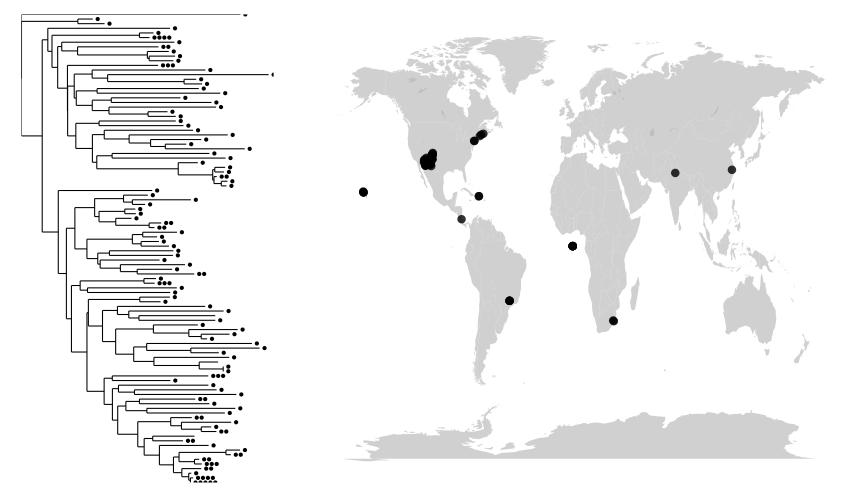

```r
#simple map + tree
map_tree(epoxomicin_KS)
```

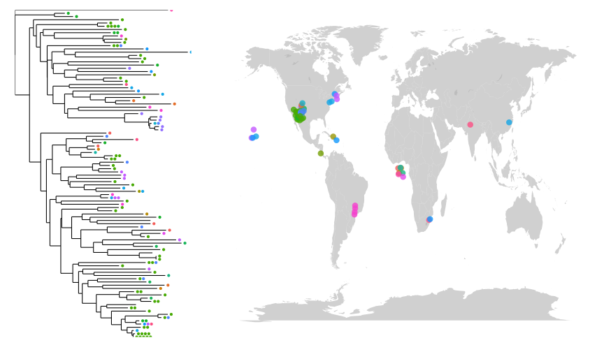

```r
#color the map to see locations
map_tree(epoxomicin_KS, color="Geotype", jitter=TRUE)
```

```r
#trim samples and locations
#x <- prune_samples()
#y <- subset_taxa()
# map_tree(y, color="Geotype", jitter=TRUE)
```

### map_clusters

*map_clusters* provides a way to explore the spatial distribution of subsets of your data. From your phylogentic tree (required), a distance matrix is used to make a kmeans calculation which will cluster your tree into *k* number of clusters. The members of these clusters will then be displayed on the map.

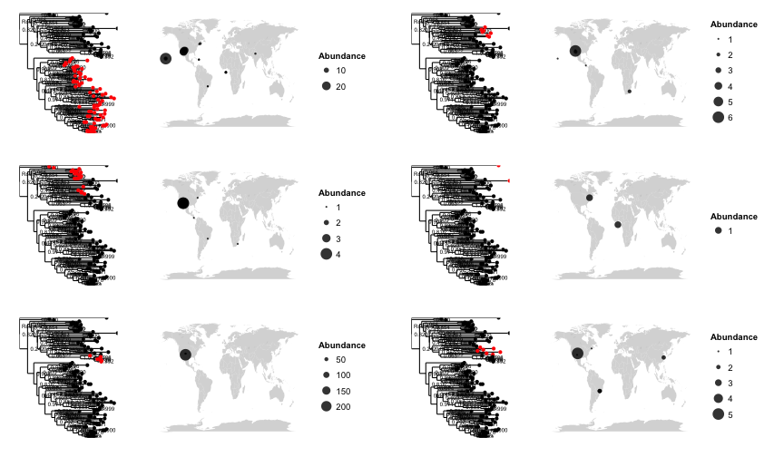

```r
#clustered trees plus maps
map_clusters(epoxomicin_KS, clusternum=6)
```

## phyloseq plotting functions

### plot_distance

This function creates a scatterplot of distances comparing the geographic great-circle distance to the the ecological distance (default:jaccard).

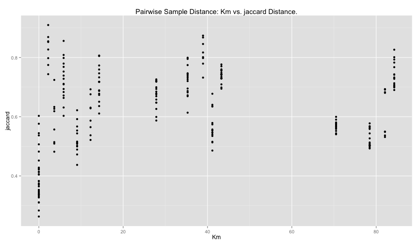

```r
plot_distance(mountainsoil)
```